# Titanic Survival Data Set

## by Ahmed Kamel Hassan

## Investigation Overview

> our goal from this investigation that to get the relationship between survival passenger with respect to the other variables in dataset and predict the factors that may affect the rate of survivors

## Dataset Overview

> The relationship between some data such as "gender, age, category" and its relationship to the extent to which the passengers survived or not, will be shown.

## Class of passengers versus number of non-survivors

> The better the passenger class, the fewer deaths

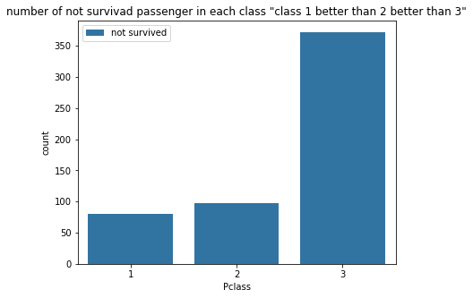

## Mean age of survived in each class

> as better the passenger class (1>2>3), mean age of passengers who survived ( and also not survived ) increased, in general mean age of passengers who died (in each class) was higher than the mean age of survived passengers.

> It can be concluded that the less the passenger age, the greater the chance of survival in general whatever class of passenger.

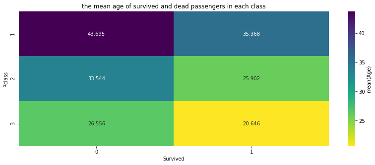

## the gender of survived passenger in each class

> number of survived females in each class is higher than survived males, in spite of the number of females in each class in less than males

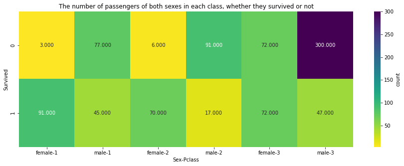

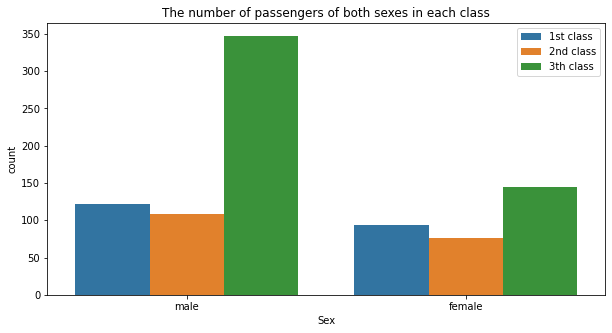